# Repaso de probabilidad

León Berdichevsky Acosta

30 de agosto de 2018

> “Probabilidad es el lenguaje matemático para cuantificar incertidumbre.” -Wasserman

En estas notas abordamos los siguientes temas:

1. Conceptos de probabilidad.
2. Interpretación frecuentista de la probabilidad.
3. Probabilidad condicional, independencia y la Regla de Bayes.
4. Variables aleatorias.

## Conceptos de Probabilidad

### Espacio de resultados y eventos

El **espacio de resultados** $\Omega$ es el conjunto de posibles resultados de un experimento aleatorio. A los puntos $\omega \in \Omega$ se les conoce como resultados muestrales, realizaciones o elementos.

**Ejemplo:** Si lanzamos una moneda dos veces entonces el espacio de resultados es:

$$\Omega = \{AA, AS, SA, SS \}$$

Un **evento** es un subconjunto del espacio de resultados; los eventos usualmente se denotan por letras mayúsculas.

**Ejemplo:** El evento que el primer lanzamiento resulte águila es

$$A=\{AA, AS\} \subset \Omega$$

### Eventos equiprobables

La probabilidad se puede ver como una extensión de la idea de **proporción**, o cociente de una parte con respecto a un todo.

**Ejemplo:** Si en la carrera de matemáticas del ITAM hay 300 estudiantes hombres y 700 mujeres, la proporción de hombres es:
$$\frac{300}{700+300}=0.3$$
Ahora, supongamos que elegimos un estudiante al azar, la probabilidad de elegir una mujer es $0.7$.

En el ejemplo hay un supuesto implícito en elegir al azar (o aleatoriamente): en este caso estamos suponiendo que todos los estudiantes tienen la misma probabilidad de ser elegidos, que nos lleva al siguiente concepto:

**Eventos equiprobables**. Si todos los elementos en el espacio de resultados tienen la misma oportunidad de ser elegidos entonces la probabilidad del evento A es el número de elementos en A dividido entre el número total de posibles resultados o elementos en $\Omega$:

$$P(A)=\frac{\#(A)}{\#(\Omega)}$$

Esto signific que si conocemos el espacio de resultados $\Omega$ lo único que tenemos que hacer para calcular probabilidades es contar.

**Ejemplo:** La probabilidad de obtener $AA$ si lanzamos una moneda dos veces es $1/4 = 0.25$, y la probabilidad del evento que la primer lanzamiento resulte águila es $2/4 = 0.5$.

**Ejercicio 1:** Lanzamos un dado y anotamos el número de la cara superior, después lanzamos otro dado y anotamos el número de la cara superior:

- ¿Cuál es el espacio de resultados?
- ¿Cuál es la probabilidad de que la suma de los números sea 5?
- ¿Cuál es la probabilidad de que el segundo número sea mayor que el primero?
- Repite las preguntas anteriores cuando lanzas 2 dados con $n$ caras ($n \ge 4$).

**Ejemplo: combinaciones.** Un comité de 5 personas será seleccionado de un grupo de 6 hombres y 9 mujeres. Si la selección es aleatoria, ¿cuál es la probabilidad del evento *E* que el comité este conformado por 3 hombres y 2 mujeres?

Hay $\dbinom{15}{5}$ posibles comités (coeficiente binomial o combinaciones de 15 en 5). Cada comité tiene la misma posibilidad de ser seleccionado. Por otra parte, hay $\dbinom{6}{3} \dbinom{9}{2}$ posibles comités que incluyen 3 hombres y 2 mujeres. Por lo tanto, la probabilidad que buscamos es:
$$P(E)=\frac{\dbinom{6}{3} \dbinom{9}{2}}{\dbinom{15}{5}}$$

y la función para calcular combinaciones en R es `choose(n, r)`:

```r
choose(6, 3) * choose(9, 2) / choose(15, 5)
```

```
#> [1] 0.24
```

## Interpretación frecuentista de probabilidad

Ya tenemos una interpretación intuitiva de probabilidad pero nos deja abierta la pregunta de como interpretar probabilidades en aplicaciones.

En el curso veremos dos interpretaciones de probabilidad:

1. La **interpretación frecuentista**, en la cuál las probabilidades se entienden como una aproximación matemática de frecuencias relativas cuando la frecuencia total tiende a infinito.
2. La **interpretación subjetiva**, en la que un enunciado de probabilidad expresa la opinión de un individuo respecto a la certeza de que ocurra un evento.

Por ahora nos concentramos en la interpretación frecuentista. Una **frecuencia relativa** es una proporción que mide que tan seguido, o frecuente, ocurre una u otra cosa en una sucesión de observaciones. Pensemos en un experimento que se pueda repetir (por ejemplo, lanzar una moneda, lanzar un dado, el nacimiento de un bebé). Llamaremos **ensayo** a una repetición del experimento. Ahora, sea $\alpha$ un posible resultado de un ensayo (obtener sol, obtener un 6, el bebé es niña). Si $\alpha$ ocurre $m$ veces en $n$ ensayos, entonces la frecuencia relativa de $\alpha$ en $n$ ensayos es $m/n$.

**Ejemplo:** Supongamos que lanzamos una moneda 10 veces y obtenemos los siguientes resultados:

```r
set.seed(2071)
lanzamientos_10 <- sample(c("A", "S"), 10, replace = TRUE)
lanzamientos_10
```

```
#>  [1] "S" "S" "S" "S" "A" "S" "S" "S" "S" "S"
```

Podemos calcular la secuencia de frecuencias relativas de obtener águila:

```r
cumsum(lanzamientos_10 == "A") # suma acumulada de águilas
```

```
#>  [1] 0 0 0 0 1 1 1 1 1 1
```

```r
cumsum(lanzamientos_10 == "A") / 1:10
```

```
#>  [1] 0.00 0.00 0.00 0.00 0.20 0.17 0.14 0.12 0.11 0.10
```

Una regla general, es que las frecuencias relativas basadas en un número mayor de observaciones son fluctuan menos comparado con las frecuencias relativas basadas en pocas observaciones. Este fenómeno se conoce como la **ley empírica de los promedios**.

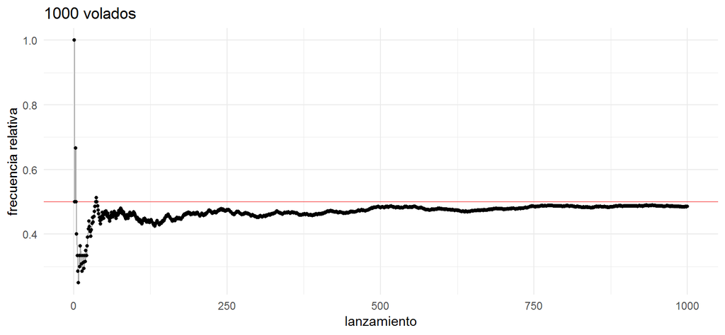

```r
set.seed(204873)
n <- 1000
data_frame(num_lanzamiento = 1:n, lanzamiento = sample(c("A", "S"), n, replace = TRUE)) %>%
    mutate(frec_rel = cummean(lanzamiento == "A")) %>%
    ggplot(aes(x = num_lanzamiento, y = frec_rel)) +
        geom_hline(yintercept = 0.5, color = "red", alpha = 0.5) +
        geom_line(color = "darkgray") +
        geom_point(size = 1.0) +
        labs(y = "frecuencia relativa", title = "1000 volados", x = "lanzamiento")
```

Ahora consideremos las frecuencias relativas para 3 series de 1000 lanzamientos.

```r
lanzar <- function(n = 1000){
    data_frame(num_lanzamiento = 1:n, lanzamiento = sample(c("A", "S"), n, replace = TRUE)) %>%
        mutate(frec_rel = cummean(lanzamiento == "A"))
  }
head(lanzar())
```

```
#> # A tibble: 6 x 3
#>   num_lanzamiento lanzamiento frec_rel
#>             <int> <chr>          <dbl>
#> 1               1 A              1
#> 2               2 S              0.5
#> 3               3 A              0.667
#> 4               4 S              0.5
#> 5               5 S              0.4
#> 6               6 S              0.333
```

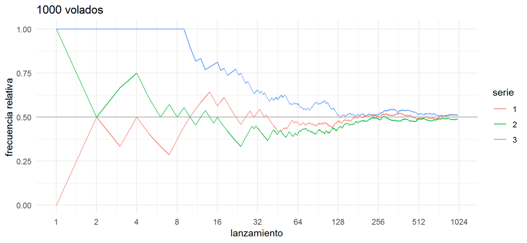

```r
set.seed(31287931)
# usamos la función map_df del paquete purrr
map_df(1:3, ~lanzar(), .id = "serie") %>%
    ggplot(aes(x = log(num_lanzamiento), y = frec_rel, color = as.character(serie))) +
        geom_hline(yintercept = 0.5, color = "darkgray") +
        geom_line() +
        scale_x_continuous("lanzamiento", labels = exp,
            breaks = log(sapply(0:10, function(i) 2 ^ i))) +
        labs(color = "serie", y = "frecuencia relativa", title = "1000 volados")
```

En la **interpretación frecuentista**, la probabilidad de un evento $A$ es la estimación de la frecuencia relativa de $A$ cuando el número de ensayos tiende a infinito. Si denotemos la proporción de veces que ocurre $A$ en $n$ ensayos por $P_n(A)$, se espera que $P_n(A)$ sea cercana a la probabilidad $P(A)$ si $n$ es *grande*:
$$P_n(A) \approx P(A), \quad n\gg 1$$

Esta idea se precisará más adelante cuando estudiemos la **ley de los grandes números**.

Veamos un ejemplo de probabilidad como frecuencia relativa; el objetivo es entender cómo la interpretación frecuentista nos da el nivel de detalle correcto cuando suponemos resultados equiprobables.

**Ejemplo: Lanzamiento de dos monedas.** Supongamos que lanzamos dos monedas de manera simultánea. ¿Cuál es la probabilidad de que las dos monedas sean águila?

La respuesta corrcta no es algo que se pueda juzgar usando únicamente matemáticas, sino que depende de los supuestos para calcular frecuencias relativas en ensayos.

1. A pesar de que las monedas son similares supongamos que se pueden distinguir, llamémoslas moneda 1 y moneda 2. Ahora tenemos cuatro posibles resultados: AA, AS, SA, SS, (la primer letra corresponde a la cara observada en la moneda 1 y la segunda en la moneda 2).
2. Si estos 4 resultados son igualmente probables entonces el evento AA tiene posibilidad de 1/4.

En este caso, las frecuencias relativas para 10,000 repeticiones del experimento es:

```r
set.seed(31287931)
n <- 10000
moneda_1 <- sample(c("A", "S"), n, replace = TRUE)
moneda_2 <- sample(c("A", "S"), n, replace = TRUE)
sum(moneda_1 == moneda_2 & moneda_1 =="A") / n
```

```
#> [1] 0.25
```

Y la probabilidad tenderá a la respuesta correcta del punto 2. cuando el número de experimentos tienda a infinito.

Más aún, hay ejemplos donde el supusto de equiprobabilidad no es adecuado (ej. cuando las monedas no son “justas”, o el sexo de un bebé recién nacido, etc.).

### Simulación para el cálculo de probabilidades

En el ejemplo anterior vimos que puede ser sencillo usar simulación para aproximar las probabilidades, pues usando la interpretación de frecuencia relativa simplemente hace falta simular el experimento y contar los casos favorables entre el total de casos. Veamos un ejemplo más para familiarizarnos con este uso de simulación.

**Ejemplo: La ruina del jugador.**

- Un jugador tiene $100, y va a apostar en un juego donde la probabilidad de ganar es p = 0.47 (e.g. una ruleta 18/38), si gana recibe el doble de lo que arriesgó, si no gana pierde todo lo que apostó.
- Cada vez que juega puede apostar cualquier cantidad siempre y cuando sea menor o igual al dinero que tiene en ese momento.
- El jugador dejará de jugar cuando su capital sea $0 o cuando gane $200.
- El jugador busca una estrategia que le ayude a aumentar su probabilidad de ganar y te pregunta:
  1. ¿Cuál es la probabilidad de ganar si apuesto en incrementos de $5 cada vez que apuesto?
  2. ¿Cuál es la probabilidad si apuesto todo en una jugada?

```r
apostar <- function(dinero = 100, apuesta = 5, tope = 200, p = 0.47){
    while(0 < dinero & dinero < tope){
        if(runif(1) < p){
            dinero <- dinero + apuesta
        }
        else{
            dinero <- dinero - apuesta
        }
    }
    dinero > 0
}
n_juegos <- 5000
juegos <- rerun(n_juegos, apostar()) %>% flatten_dbl()
mean(juegos)
```

```
#> [1] 0.089
```

```r
juegos <- rerun(n_juegos, apostar(apuesta = 100)) %>% flatten_dbl()
mean(juegos)
```

```
#> [1] 0.47
```

La solución analítica la pueden leer en este documento de [caminatas aleatorias](http://web.mit.edu/neboat/Public/6.042/randomwalks.pdf):

```r
p = 0.47
1 - (1 - (p / (1 - p)) ^ (100 / 5)) / (1 - (p / (1 - p)) ^ (200 / 5)) # apostando de 5 en 5
```

```
#> [1] 0.083
```

```r
1 - (1 - (p / (1 - p)) ^ (100 / 100)) / (1 - (p / (1 - p)) ^ (200 / 100)) # apostando de 100 en 100
```

```
#> [1] 0.47
```

**Ejercicio 2: Urna.** 10 personas (con nombres distintos) escriben sus nombres y los ponen en una urna, después seleccionan un nombre (al azar) cada uno.

- Sea A el evento en el que ninguna persona selecciona su nombre, ¿Cuál es la probabilidad del evento A?
- Supongamos que hay 3 personas con el mismo nombre, ¿Cómo calcularías la probabilidad del evento A en este nuevo experimento?

### Probabilidad: definición matemática

Desde un punto de vista puramente matemático, la probabilidad se define como una función de eventos. Los eventos se representan como conjuntos, y suponemos que la función de probabilidad satisface las reglas básicas de proporción. Antes de definir estas reglas consideremos la representación de los eventos como subconjuntos de un espacio de resultados.

Supongamos que tenemos un espacio de resultados $\Omega$, y que todos los eventos de interés están representados como subconjuntos de $\Omega$. Podemos pensar en $\Omega$ como una representación de todas las situaciones que pueden ocurrir, no suponemos que es finito (ni discreto), ni que los eventos son igualmente probables.

Las reglas de la probabilidad involucran relaciones lógicas entre eventos; estas se traducen a relaciones de conjuntos. Por ejemplo, si C es el evento que ocurre si sucede A o si sucede B, entonces el conjunto de maneras en las que ocurre C es la unión del conjunto de maneras en que ocurre A y el conjunto de maneras en que ocurre B. Veamos como se traduce de eventos a conjuntos:

| Lenguaje de eventos | Lenguaje de conjuntos | Notación de conjuntos |
| --- | --- | --- |
| Espacio de resultados | conjunto universal | $\Omega$ |
| evento | subconjunto de $\Omega$ | $A,B,C,...$ |
| evento imposible | conjunto vacío | $\emptyset$ |
| no A, opuesto de A | complemento de A | $A^c$ |
| A o B | unión de A y B | $A\cup B$ |
| tanto A como B | intersección de A y B | $AB,A\cap B$ |
| A y B mutuamente excluyentes | A y B disjuntos | $AB=\emptyset$ |
| si A entonces B | A es subconjunto de B | $A\subset B$ |

#### Particiones y axiomas de probabilidad

Decimos que un conjunto de $n$ eventos (subconjuntos) $B_1,...,B_n$ es una **partición** del evento $B$ si $B=B_1 \cup B_2 \cup \cdot\cdot\cdot \cup B_n$ y los eventos $B_1,...,B_n$ son **mutuamente excluyentes**.

Una función $P$ es una **función de probabilidad** si satisface las siguientes condiciones (axiomas):

1. Para cualquier evento $B$, el valor de probabilidad debe ser no-negativo:
   $$P(B) \geq 0$$
2. La suma de las probabilidades a través de todos los posibles elementos en el espacio de resultados debe ser 1 (esto es, por lo menos uno de los elementos del espacio de resultados debe ocurrir):
   $$P(\Omega) = 1$$
3. Si $B_1,...,B_n$ es una partición del evento $B$ entonces, la probabilidad de que ocurra B es la suma de las probabilidades individuales:
   $$P(B)=P(B_1)+P(B_2) + \cdot\cdot\cdot +P(B_n)$$

##### Propiedades de la función de probabilidad:

- $P(A^c) = 1 - P(A)$
- $P(\emptyset)=0$
- Si $A \subset B$ entonces $P(A) \le P(B)$
- $0\le P(A) \le 1$
- La regla general de la suma: $P(A \cup B) = P(A) + P(B) - P(A \cap B)$

#### Distribuciones de probabilidad

Una **distribución de probabilidad** es simplemente una lista de todos los elementos del espacio de resultados y sus probabilidades correspondientes (en el caso discreto):

| resultado $\omega$ | a | b | c | d | e | $\cdot\cdot\cdot$ |
| --- | --- | --- | --- | --- | --- | --- |
| **probabilidad $P(\omega)$** | $P(a)$ | $P(b)$ | $P(c)$ | $P(d)$ | $P(e)$ | $\cdot\cdot\cdot$ |

##### Distribución empírica

Sea $(x_1,x_2,...,x_n)$ una lista de $n$ números; podemos pensar que $x_i$ es la i-ésima medición de algo en una serie de mediciones. La **distribución empírica** de la lista de $n$ números es la distribución en la línea $(-\infty, \infty)$ definida como
$$P_n(a,b)=\#\{i: 1 \le i \le n, a < x_i < b\}/n$$

Esto es, $P_n(a,b)$ es la proporción de los $n$ números en la lista que se ubican en el intervalo $(a,b)$.

Para entender la interpretación probabilística, imaginemos $n$ boletos en una caja, cada boleto tiene escrito el número $x_i$, después elegimos un boleto al azar y $P_n(a,b)$ es la probabilidad de que el número escrito en el boleto que elegimos caiga en el intervalo $(a,b)$. Entonces, la distribución empírica de una lista es la distribución de un número elegido de manera aleatoria de la lista.

Podemos mostrar la distribución empírica de una lista de datos mediante un histograma.

**Ejemplo:** Veamos un caso donde el valor de $x_i$ es discreto (y finito). Considere una muestra aleatoria de 100 lanzamientos de un dado:

```r
dado <- read_delim("data/dado.csv", " ", escape_double = FALSE, trim_ws = TRUE)
prop.table(table(dado$observado))
```

```
#>
#>    1    2    3    4    5    6
#> 0.13 0.19 0.10 0.17 0.14 0.27
```

En este caso la lista es (1, 2, 3, 4, 5 o 6) y la distribución empírica de la lista es (0.13, 0.19, 0.10, 0.17, 0.14, 0.27), por lo que ésta se describe con una gráfica de barras:

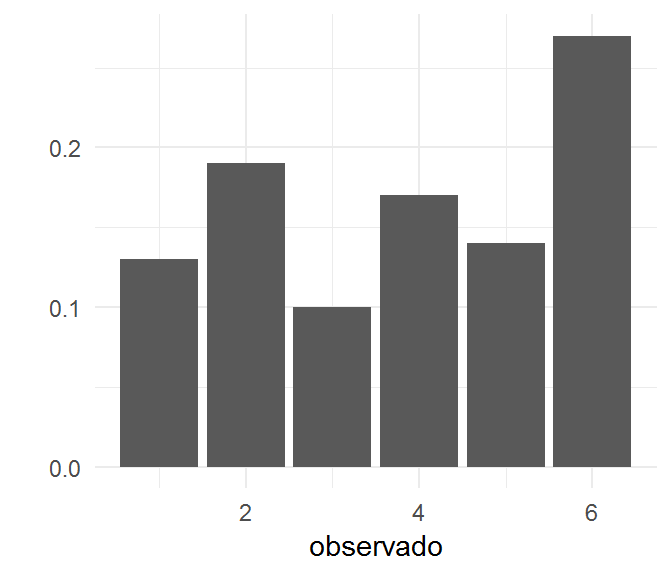

```r
ggplot(dado, aes(x = observado)) +
    geom_bar(aes(y = ..prop..)) +
    labs(y = "")
```

**Ejemplo:** Veamos un caso donde el valor de $x_i$ es continuo. Inspeccionaremos la distribución empírica de la variable ozono en la base de datos `airquality`:

```r
data(airquality)
glimpse(airquality)
```

```
#> Observations: 153
#> Variables: 6
#> $ Ozone   <int> 41, 36, 12, 18, NA, 28, 23, 19, 8, NA, 7, 16, 11, 14, ...
#> $ Solar.R <int> 190, 118, 149, 313, NA, NA, 299, 99, 19, 194, NA, 256,...
#> $ Wind    <dbl> 7.4, 8.0, 12.6, 11.5, 14.3, 14.9, 8.6, 13.8, 20.1, 8.6...
#> $ Temp    <int> 67, 72, 74, 62, 56, 66, 65, 59, 61, 69, 74, 69, 66, 68...
#> $ Month   <int> 5, 5, 5, 5, 5, 5, 5, 5, 5, 5, 5, 5, 5, 5, 5, 5, 5, 5, ...
#> $ Day     <int> 1, 2, 3, 4, 5, 6, 7, 8, 9, 10, 11, 12, 13, 14, 15, 16,...
```

¿Cómo calculamos la probabilidad empírica de $x \in (0, 20)$?

```r
ozone_1 <- airquality$Ozone[!(is.na(airquality$Ozone))]
n <- length(ozone_1)
n # calculamos n (tamaño de muestra)
```

```
#> [1] 116
```

```r
ozone_ab <- ozone_1[0 < ozone_1 & ozone_1 < 20]
ozone_ab
```

```
#>  [1] 12 18 19  8  7 16 11 14 18 14  6 11  1 11  4 12 13 10  7 16  9 16  9
#> [24]  9 13 18 13 16 13  7 14 14 18
```

```r
n_ab <- length(ozone_ab)  # contamos cuantas observaciones pertenecen al evento (0, 20)
n_ab/n
```

```
#> [1] 0.28
```

Y podemos graficar el histograma del ozono

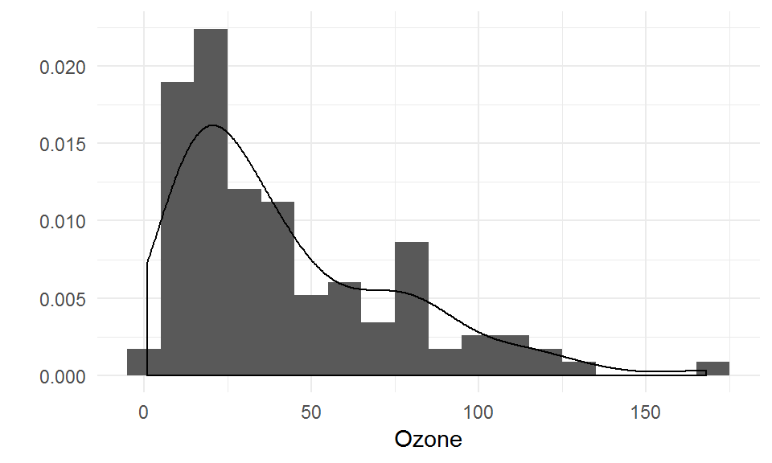

```r
ggplot(airquality, aes(x = Ozone)) +
  geom_histogram(binwidth = 10, aes(y = ..density..)) +
  geom_density() +
    labs(y = "")
```

Un histograma aproxima la forma general de la distribución empírica.

## Probabilidad condicional e independencia

Comenzaremos ilustrando la idea de probabilidad condicional mediante un ejemplo:

**Ejemplo: Lanzamiento consecutivo de una moneda.** Supongamos que lanzamos una moneda tres veces. Si apostamos que saldrán 2 o más águilas (evento $A$), tenemos mayor oportunidad de ganar si el primer lanzamiento resulta en águila en contraste con que el primer lanzamiento resulte en sol. Para ser más exactos, supongamos que las 8 posibles combinaciones de los resultados son igualmente probables (equiprobables):

```r
volado <- c("A", "S")
volados <- volado %>%
    crossing(volado) %>%
    crossing(volado)
volados
```

```
#> # A tibble: 8 x 3
#>   .     volado volado1
#>   <chr> <chr>  <chr>
#> 1 A     A      A
#> 2 A     A      S
#> 3 A     S      A
#> 4 A     S      S
#> 5 S     A      A
#> 6 S     A      S
#> 7 S     S      A
#> 8 S     S      S
```

Entonces, la probabilidad no condicional del evento $A$: que se observen al menos dos águilas es $4/8 = 0.5$.

Ahora, la probabilidad del evento $A$ dado el envento $B$: que el primer lanzamiento sea águila, se calcula a partir del siguiente espacio de resultados:

```r
volados %>%
    filter(`.` == "A")
```

```
#> # A tibble: 4 x 3
#>   .     volado volado1
#>   <chr> <chr>  <chr>
#> 1 A     A      A
#> 2 A     A      S
#> 3 A     S      A
#> 4 A     S      S
```

El evento $A$ ocurre si se observa al menos un águila en los últimos dos lanzamientos, esto tiene una probabilidad de $3/4$. Decimos que la probabilidad condicional de $A$ (que se observen al menos dos águilas) condicional a (o dado) $B$ (que el primer lanzamiento haya resultado en águila) es $3/4$ y se denota:
$$P(A \vert B) = 3/4$$
Notemos que los 3 eventos que resultan en que se gane la apuesta, condicional a que se observó un águila en el primer volado, es la intersección de los eventos $A$ y $B$.

### Probabilidad Condicional como Proporción

Para un conjunto finito $\Omega$ de resultados igualmente probables, y eventos $A$, $B$ tales que $P(B) > 0$, la **probabilidad condicional** de $A$ dado $B$ es
$$P(A\vert B)=\frac{\#(A\cap B)}{\#B}$$
la proporción de los resultados en $B$ que también están en $A$.

**Ejercicio 3:** Una urna contiene 10 sobres: 4 negros y 6 blancos, Adentro de cada sobre hay un boleto con una marca de ganar o perder, el número de boletos ganadores y perdedores es como sigue:

| sobre | ganar | perder |
| --- | --- | --- |
| blanco | 2 | 4 |
| negro | 2 | 2 |

Supongamos que se extrajo un sobre negro pero aún no se abre:

- ¿Cuál es la probabilidad de ganar condicional a que se extrajo un sobre negro?
- ¿Cómo se compara con la probabilidad no condicional de ganar?

**Ejercicio 4:** En el juego de bridge, se dividen las 52 cartas en 4 jugadores -llamados Este, Oeste, Norte y Sur,

- ¿cuál es la probabilidad de que Este tenga 3 espadas?
- Si Norte y Sur tienen un total de 8 espadas, ¿cuál es la probabilidad de que Este tenga 3 espadas de las 5 restantes?

### Interpretación frecuentista de la probabilidad condicional

Este concepto se ilustra en el ejercicio anterior, si $P(A) \approx P_n(A)$ (la frecuencia relativa de A) conforme el número de ensayos $n$ aumenta, entonces $P(A\vert B)$ se aproxima a la frecuencia relativa de ensayos que producen $A$ dentro del conjunto de ensayos en los que ocurre $B$:
$$P(A\vert B) = \frac{P(A \cap B)}{P(B)}$$

**Ejemplo: Áreas relativas.** Supongamos que tenemos un rectángulo principal ($R$) que contiene a un círculo ($B$) y a un rectángulo ($A$) más chico y que estos últimos se intersectan en su interior. Supongamos que la probabilidad de todo punto en $R$ es la misma. Supongamos ahora que la ubicación del punto se revela en 2 etapas: 1) Primero se indica si el punto está o no en el círculo, 2) Posteriormente se indica si el punto se encuentra en el rectángulo interior. Antes de obtener información acerca de si el punto se encuentra ene el círculo,
¿Cuál es la probabilidad de que el punto esté en el rectángulo interior?
$$P(A) = \frac{Área(A)}{Área(R)}$$
Ahora, si sabemos que el punto esta en el círculo, ¿cuál es la probabilidad de que el punto esté en el interior del rectángulo interior?
$$P(A\vert B) = \frac{Área(A \cap B)}{Área(B)}$$

Esto implica que áreas iguales corresponden a igual probabilidad dentro de $B$.

#### Regla de la multiplicación

En los ejemplos anteriores calculamos la probabilidad condicional a partir de probabilidades no condicionales ($P(B), P(A\cap B)$); sin embargo, en las aplicaciones es común tener eventos tales que la probabilidad condicional $P(A\vert B)$ y la probabilidad $P(B)$ son más fáciles de conocer que la probabilidad $P(A \cap B)$.

**Regla de la multiplicación**:
$$P(A \cap B) = P(A\vert B)P(B)$$

La regla de la multiplicación es muy natural en escenarios donde un evento $A$ esta determinado por un resultado que ocurre en etapas, y $B$ es un evento que depende únicamente de la primera etapa.

**Ejercicio 5: Seleccionando una camada, después un cachorro.** Supongamos que tenemos 2 camadas de labradores, en la primer camada hay 2 cachorros color negro y 2 chocolate, en la segunda camada hay 1 cachorro color negro y 2 miel. El experimento es como sigue: lanzo una moneda justa, si sale sol elijo un perro al azar de la camada uno y si el resultado es águila elijo un perro al azar de la camada dos.

- ¿Cuál es la probabilidad de que elija un perro color chocolate?

- ¿Cuál es la probabilidad de que elija un cachorro color negro?

#### Promedio de probabilidades condicionales

El ejercicio anterior ilustra la regla de del promedio de probabilidades condicionales: para cualquier par de eventos $A$ y $B$, la probabilidad total $P(A)$ es el promedio de 2 probabilidades condicionales $P(A\vert B)$ y $P(A\vert B^c)$, donde los pesos son $P(B)$ y $P(B^c)$:
$$P(A) = P(A\vert B)P(B) + P(A\vert B^c)P(B^c)$$

El evento $B$ define una partición del espacio de resultados $\Omega$ en 2 eventos $B$ y $B^c$, podemos extender la fórmula a un caso más general: sean $B_1, B_2, ..., B_n$ una partición del espacio de resultados $\Omega$, para cualquier evento $A$, los eventos $A\cap B_1,...,A\cap B_n$ forman una partición de $A$, por lo tanto
$$P(A)=P(A\cap B_1)+\cdot\cdot\cdot+P(A\cap B_n)$$
y si aplicamos la regla de la multiplicación a cada término,
$$P(A) = P(A\vert B_1)P(B_1)+\cdot\cdot\cdot+P(A\vert B_n)P(B_n)$$

**Ejemplo: muestreo con/sin reemplazo.** Supongamos que seleccionamos (al azar) dos cartas de una baraja, ¿cuál es la probabilidad de que la segunda carta sea negra?
Sean $N$ y $R$ los eventos, que la primera carta sea negra y que la primera carta sea roja, y sea $A$ el evento que la segunda carta sea negra, entonces
$$P(A) = P(A\vert N)P(N) + P(A\vert R) P(R)$$

**Ejercicio 6: Chabelo (Monty Hall).** Supongamos que estamos jugando las catafixias de Chabelo, en este juego hay 3 *catafixias*: 2 de ellas están vacías y una tiene un premio,

1. El juego comienza cuando escoges una catafixia.
2. A continuación Chabelo abre una catafixia vacía de las dos catafixias restantes.
3. Tu eliges si te mantienes con tu catafixia o cambias a la otra que continúa cerrada.
4. Chabelo abre tu segunda elección de catafixia y se revela si ganaste.

¿Cuál es la probabilidad de que ganes si cambias de catafixia?

### Regla de Bayes

Las reglas de probabilidad condicional que describimos en la sección anterior son la base de la regla de Bayes:

**Regla de Bayes**. Sea $B_1,...,B_n$ una partición del espacio de resultados $\Omega$. Entonces, para cualquier evento $A$ se tiene que:
$$P(A)P(B_i\vert A) = P(A\vert B_i)P(B_i) \quad \forall \quad i=1,...,n$$

o

$$P(B_i\vert A) = \frac{P(A\vert B_i)P(B_i)}{P(A\vert B_1)P(B_1)+ \cdot\cdot\cdot +
P(A\vert B_n)P(B_n)}$$

**Ejercicio 7: 3 camadas.** Supongamos que tenemos 3 camadas de labradores en un criadero:

| Camada | negro | miel |
| --- | --- | --- |
| 1 | 1 | 1 |
| 2 | 2 | 1 |
| 3 | 3 | 1 |

Para vender un cachorro elijo una camada de manera aleatoria, y después elijo un cachorro de manera aleatoria de la camada seleccionada y lo entrego al nuevo dueño. Sabiendo la composición de las camadas antes de extraer el cachorro, ofrezco un descuento si adivinan de que camada provino.

Si te entrego un cachorro negro ¿Qué camada seleccionarías y cuál es la probabilidad de elegir la correcta?

**Ejercicio 8.** [La intuición es engañosa](http://www.amazon.com/The-Drunkards-Walk-Randomness-Rules/dp/0307275175): En estudios en Alemania y EUA, investigadores le pidieron a médicos que estimaran la probabilidad de que una mujer asintomática entre los 40 y 50 años tuviera cáncer de mama si su mamograma era positivo. Se les explicó que el 7% de los mamogramas indican cáncer cuando no lo hay (falsos positivos). Adicional mente, se le explicó a los médicos que la incidencia de cáncer de mama en ese grupo de edad es 0.8% y la tasa de falsos negativos de 10%. En Alemania, un tercio de los médicos determinaron que la probabilidad era cercana al 90% y la mediana de las estimaciones fue 70%. En EUA 95 de 100 médicos estimaron que la probabilidad rondaba el 75%. ¿Cómo determinas la probabilidad de que una mujer con mamograma positivo tenga cáncer?

##### Observaciones

1. $P(\cdot\vert B)$ satisface las reglas de probabilidad para una $B$ fija. En general, $P(A\vert \cdot)$ no satisface las reglas de probabilidad para una $A$ fija.
2. En general $P(A\vert B) \ne P(B\vert A)$.

### Independencia

Dos eventos, $A$, $B$ son **independientes** si y solo si la probabilidad de que ocurra $B$ no depende de si ocurre $A$ o no:

$$P(B\vert A) = P(B\vert A^c) = P(B)$$

esto es equivalente a la **regla de la multiplicación de eventos independientes**: $A$, $B$ son **independientes** si y solo si la probabilidad de la intersección es el producto de las probabilidades:
$$P(A\cap B) = P(A)P(B)$$

La idea de independencia para más de dos eventos es una extensión natural de la independencia de dos eventos. Por ejemplo, los eventos $A$, $B$ y $C$ son independientes si se satisface la **regla de la multiplicación de eventos independientes**:
$$P(ABC)=P(A)P(B)P(C)$$

##### Suponer independencia o derivar independencia

La independencia puede surgir de dos maneras:

1. Algunas veces suponemos de manera explícita que dos eventos son independientes. Por ejemplo, cuando lanzamos una moneda dos veces, usualmente asumimos que los lanzamientos son independientes, y esto refleja que la moneda no tiene memoria.
2. En otras ocasiones derivamos la independencia verificando que $P(A \cap B) = P(A)P(B)$. Por ejemplo, cuando lanzamos un dado justo: sea $A=\{2,4,5\}$ y $B=\{1,2,3,4\}$, entonces $A\cap B = \{2,4\}$, $P(A \cap B)=2/6 = P(A)P(B)$, por tanto $A$ y $B$ son independientes.

**Pregunta:** Supongamos que $A$ y $B$ son dos eventos mutuamente excluyentes, tales que $P(A)>0$ y $P(B)>0$ ¿pueden $A$ y $B$ ser independientes?

## Variables aleatorias

La estadística esta ligada a datos, por tanto debemos encontrar una manera de relacionar el espacios de resultados y los eventos a los datos: la liga es el concepto de variable aleatoria.

Una **variable aleatoria** $X$ es un mapa entre el espacio de resultados y los números reales:
$$X: \Omega \rightarrow \mathbb{R}$$
$$\quad \quad \quad \omega \mapsto X(\omega)=x$$

Al conjunto de valores que puede tomar $x$ se le denomina **soporte** de la variable aleatoria $X$ y se denota como $\Omega_X$.

##### Ejemplos

1. Supongamos que lanzamos una moneda 2 veces. Definimos $X(\omega)$ como el número de veces que obtenemos águila en la sucesión $\omega$. Por ejemplo, si $\omega=AA$ entonces $X(\omega)=2$; podemos hacer la tabla completa de posibilidades:

| $\omega \in \Omega$ | AA | AS | SA | SS |
| --- | --- | --- | --- | --- |
| $X(\omega) = x$ | 2 | 1 | 1 | 0 |

Si observamos el segundo renglón de la tabla notamos que el soporte de $X$ es $\Omega_X=\{0, 1, 2\}$.

2. Supongamos que lanzamos una moneda hasta observar un águila, en esta caso el espacio de resultados es $\Omega=\{A, SA, SSA, SSSA,...\}$. Definimos la variable aleatoria $Y$ como el número de soles antes de observar la primer águila, entonces el soporte de $Y$ es $\Omega_Y=\{0, 1, 2, ...\}$.
3. Sea $\Omega=\{(x,y): x^2 + y^2 \le 1\}$ el círculo unitario. Consideremos seleccionar un punto de manera aleatoria de $\Omega$, por lo que un resultado típico es de la forma $\omega=(x, y)$. Podemos definir una variable aleatoria de diferentes maneras, por ejemplo:
1. $X(\omega)=x$,
2. $Y(\omega)=y$,
3. $Z(\omega)=x+y$,
4. $W(\omega)=\sqrt{x^2+y^2}$, etc.

Otra manera de ver una variable aleatoria es como una variable cuyo valor esta determinado por el resultado de un experimento aleatorio.

Ahora, dada una variable aleatoria $X$ y un subconjuto $\mathcal{A}=(a,b)$ de la recta real definimos el evento $A$ como
$$A = X^{-1}(\mathcal{A}) = \{\omega \in \Omega: X(\omega) \in \mathcal{A}\}$$
entonces, podemos definir una función de probabilidad $P$ que actúa sobre el soporte de $X$ $\Omega_X \in \mathbb{R}$ como sigue:
$$P(X \in \mathcal{A}) = P(X^{-1}(\mathcal{A})) = P(A) = P(\{\omega \in \Omega: X(\omega) \in \mathcal{A}\})$$

**Ejemplo:** Volviendo al ejemplo 1. del lanzamiento de una moneda dos veces, si definimos el subconjunto de los reales como $\mathcal{B} = 1$ y debido a que el evento asociado $B$ es $B=X^{-1}(\mathcal{B}) = \{AS,SA\}$,entonces la probabilidad de la variable aleatoria $X$ es $P(X \in \mathcal{B}) = 1/2$.

Si $X$ toma únicamente un número finito de valores, la distribución de $X$ está determinada por las probabilidades de los valores individuales:
$$P(X = x), \quad x \in \Omega_X$$
La regla de la suma implica que:
$$P(X \in \mathcal{A}) = \sum_{x \in \mathcal{A}}P(X = x)$$

Dos variables aleatorias tienen la misma distribución si $X$ e $Y$ tienen el mismo soporte, y si para cualquier valor $v$ en el soporte
$$P(X=v)=P(Y=v)$$
.

### Esperanza

La **esperanza** (**valor esperado** o **media**) de una variable aleatoria $X$, es la media de la distribución de $X$, esto es,
$$E(X)=\sum_{x\in \Omega_x} x P(X=x)$$
el promedio de todos los posibles valores de $X$ ponderados por sus probabilidades.

La esperanza es una medida de tendencia central de la distribución de $X$.

**Ejemplo:** Si $X$ toma únicamente dos posibles valores, $a$ y $b$ con probabilidad $P(a)$ y $P(b)$ entonces
$$E(X)=aP(a)+bP(b).$$

**Ejemplo:** Supongamos que $X$ es el valor que se produce cuando tiro un dado justo. Entonces,
$$E(X)=1\cdot P(X=1) +2\cdot P(X=2) +3\cdot P(X=3) +4\cdot P(X=4) +5\cdot P(X=5) +6\cdot P(X=6) = 3.5$$
Lo que nos dice que si tiramos el dado muchas veces deberíamos esperar que el promedio de las tiradas sea cercano a 3.5.

**Esperanza como un promedio de frecuencias relativas cuando $n$ es grande**. Si vemos las probabilidades de los valores de $X$ como una aproximación de frecuencias relativas cuando el número de ensayos $n$ es grande, entonces $E(X)$ es aproximadamente el valor promedio del valor que toma en los ensayos $X$ cuando $n$ es grande.

```r
x <- rnorm(10000, mean = 10)
mean(x)
```

```
#> [1] 10
```

La esperanza satisface las siguientes propiedades:

1. **Constantes**. La esperanza de una variable aleatoria constante es su valor constante,
   $$E(c) = c$$
2. **Indicadoras**. Si $I_A$ es la función indicadora del evento $A$,
   $$E(I_A) = P(A)$$
3. **Funciones**. Típicamente, $E[g(X)]\ne g[E(X)]$, pero
   $$E[g(X)] = \sum_{x \in \Omega_X} g(x) P(X=x)$$
4. **Factores constantes**. Para una constante c,
   $$E(cX)=cE(X)$$
5. **Adición**. Para cualquier par de variables aleatorias $X$, $Y$,
   $$E(X+Y) = E(X)+E(Y)$$
6. **Multiplicación**. Típicamente $E(XY) \ne E(X)E(Y)$, pero si $X$ y $Y$ son independientes, entonces
   $$E(XY)=E(X)E(Y)$$

### Varianza y desviación estándar

Si intentamos predecir el valor de una variable aleatoria usando su media $E(X)=\mu$, vamos a fallar por una cantidad aleatoria $X-\mu$. Suele ser importante tener una idea de que tan grande será esta desviación. Debido a que
$$E(X-\mu) = E(X)-\mu=0$$
es necesario considerar la diferencia absoluta o la diferencia al cuadrado de $X-\mu$ con el fin de tener una idea del tamaño de la desviación sin importar el signo de esta.

**Varianza y desviación estándar**. La varianza de $X$, denotada $var(X)=\sigma^2$ es la media de la desviación cuadrada de $X$ respecto a su valor esperado $\mu=E(X)$:
$$\sigma^2(X)=var(X)=E(X-\mu)^2$$
La desviación estándar de $X$, es la raíz cuadrada de la varianza de X:
$$\sigma(X)=se(X)=\sqrt{var(X)}$$

Intuitivamente, $se(X)$ es una medida de la dispersión de la distribución de $X$ alrededor de su media. Debido a que la varianza es el valor esperado de la distribución de $(X-\mu)^2$, su raíz cuadrada da una idea del tamaño típico de la desviación absoluta $|X-\mu|$. Notemos que $E(X)$, $var(X)$ y $se(X)$ están determinados por $X$, de tal manera que si dos variables aleatorias tienen la misma distribución, también tienen la misma media, varianza y desviación estándar.